# 04 · Protein classification

## Load packages

```r
pacman::p_load(here, dplyr, tidyr, purrr, ggplot2, readxl, writexl)
here::i_am(
  "02_Differential_Expression/04_Protein_Classification/a_script/04_protein_classification.qmd"
)
```

## Read proteins and earlier results

`proteins` holds the normalised, blood-adjusted log2 abundances (`E`), the sample table and the gene annotation. `genes` maps each protein to its gene symbol, falling back to the protein identifier. The `DEP_matrix` sheet of `02_Differential` and the `associations` sheet of `03_Protein_Association` are only used for the candidate list at the end.

```r
stage <- here("02_Differential_Expression", "04_Protein_Classification")
proteins <- readRDS(here("01_Preprocess", "02_Quantification", "c_data", "proteins_adjusted.rds"))
targets <- proteins$targets
values <- proteins$E
genes <- set_names(coalesce(proteins$genes$Genes, rownames(proteins)), rownames(proteins))
de <- read_excel(
  here("02_Differential_Expression", "02_Differential", "c_data", "02_differential.xlsx"),
  "DEP_matrix"
)
associations <- read_excel(
  here(
    "02_Differential_Expression", "03_Protein_Association", "c_data",
    "03_protein_association.xlsx"
  ),
  "associations"
)

dim(values)
```

```
[1] 3042  131
```

## Pair the samples

Each leg has a sample before training (T1) and after (T2). Widening on timepoint gives one row per leg with both sample identifiers; `legs` keeps those with both.

```r
by_timepoint <- targets |>
  mutate(leg_id = paste(participant, leg, sep = "_")) |>
  select(leg_id, participant, leg, treatment, timepoint, sample_id) |>
  pivot_wider(names_from = timepoint, values_from = sample_id)
legs <- drop_na(by_timepoint, T1, T2) |> arrange(participant, treatment)

head(legs)
```

```
# A tibble: 6 × 6
  leg_id participant leg   treatment T1       T2
  <chr>  <chr>       <chr> <chr>     <chr>    <chr>
1 S02_R  S02         R     BFR       S02_R_T1 S02_R_T2
2 S02_L  S02         L     HLRT      S02_L_T1 S02_L_T2
3 S03_R  S03         R     BFR       S03_R_T1 S03_R_T2
4 S03_L  S03         L     HLRT      S03_L_T1 S03_L_T2
5 S04_R  S04         R     BFR       S04_R_T1 S04_R_T2
6 S04_L  S04         L     HLRT      S04_L_T1 S04_L_T2
```

`pair_by_treatment()` puts each participant’s BFR and HLRT legs side by side, one row per participant; participants without both legs drop out. It gives three pairings: baseline samples, post samples, and legs for the change scores.

```r
pair_by_treatment <- function(data, column) {
  data |>
    select(participant, treatment, value = all_of(column)) |>
    pivot_wider(names_from = treatment, values_from = value) |>
    drop_na(BFR, HLRT)
}
baseline <- pair_by_treatment(by_timepoint, "T1")
post <- pair_by_treatment(by_timepoint, "T2")
delta_pairs <- pair_by_treatment(legs, "leg_id")

c(baseline = nrow(baseline), post = nrow(post), delta = nrow(delta_pairs))
```

```
baseline     post    delta
      33       32       32
```

```r
head(baseline)
```

```
# A tibble: 6 × 3
  participant HLRT     BFR
  <chr>       <chr>    <chr>
1 S02         S02_L_T1 S02_R_T1
2 S03         S03_L_T1 S03_R_T1
3 S04         S04_L_T1 S04_R_T1
4 S05         S05_L_T1 S05_R_T1
5 S06         S06_R_T1 S06_L_T1
6 S07         S07_R_T1 S07_L_T1
```

The protein change per leg is T2 minus T1 on the log2 scale, one column per leg.

```r
delta <- values[, legs$T2] - values[, legs$T1]
colnames(delta) <- legs$leg_id
```

## Define the tasks

Three paired tasks, each comparing a participant’s BFR leg with their HLRT leg. Each holds its matrix and two paired column sets, `positive` (BFR) and `negative` (HLRT). Pre-to-post within an arm is tested in `02_Differential`, with more power, and for sets in `03_Pathway_Enrichment/04_set_classification`. The baseline task compares the legs before training, when nothing should separate them.

```r
tasks <- list(
  baseline_BFR_vs_HLRT = list(
    values = values, positive = baseline$BFR, negative = baseline$HLRT,
    label = "Baseline BFR vs HLRT"
  ),
  post_BFR_vs_HLRT = list(
    values = values, positive = post$BFR, negative = post$HLRT, label = "Post BFR vs HLRT"
  ),
  delta_BFR_vs_HLRT = list(
    values = delta, positive = delta_pairs$BFR, negative = delta_pairs$HLRT,
    label = "Change, BFR vs HLRT"
  )
)

map_int(tasks, function(spec) length(spec$positive))
```

```
baseline_BFR_vs_HLRT     post_BFR_vs_HLRT    delta_BFR_vs_HLRT
                  33                   32                   32
```

## Score each protein

A ROC curve plots, for every cut-off on a protein’s abundance, the share of positive samples above it (sensitivity) against the share of negative samples above it (1 - specificity). The area under it, AUC, is the probability that a random positive sample sits higher than a random negative one: 0.5 is no separation, 1 perfect, 0 perfect the other way. `pROC::roc()` auto-orients, so a true AUC of 0.194 would come back as 0.806; `direction = "<"` in `fit_roc()` pins it.

```r
fit_roc <- function(values, spec) {
  pROC::roc(
    controls = values[spec$negative], cases = values[spec$positive],
    direction = "<", quiet = TRUE
  )
}
```

AUC ignores the pairing, so p comes from the paired Wilcoxon signed-rank test, which ranks the within-pair differences by size and asks whether positive and negative differences balance. Benjamini–Hochberg (BH) adjustment turns p into `fdr`, the false discovery rate at which the protein would be called, within each task.

```r
# The argument is `spec`, not `task`: tibble() builds a `task` column first, and a later
# `task$label` in the same call would read that column instead of the argument.
protein_auc <- imap(tasks, function(spec, name) {
  tibble(
    task = name, task_label = spec$label, protein = rownames(spec$values),
    gene = genes[rownames(spec$values)], n_pairs = length(spec$positive),
    auc = apply(spec$values, 1, function(row) as.numeric(pROC::auc(fit_roc(row, spec)))),
    p_paired = apply(spec$values, 1, function(row) {
      wilcox.test(row[spec$positive], row[spec$negative], paired = TRUE)$p.value
    })
  )
}) |>
  list_rbind() |>
  mutate(fdr = p.adjust(p_paired, "BH"), .by = task)

protein_auc |>
  slice_min(p_paired, n = 3, by = task) |>
  select(task, protein, gene, auc, p_paired, fdr)
```

```
# A tibble: 9 × 6
  task                 protein gene     auc  p_paired   fdr
  <chr>                <chr>   <chr>  <dbl>     <dbl> <dbl>
1 baseline_BFR_vs_HLRT P04844  RPN2   0.294 0.0000417 0.127
2 baseline_BFR_vs_HLRT Q14914  PTGR1  0.356 0.000267  0.294
3 baseline_BFR_vs_HLRT Q8WVI0  SMIM4  0.311 0.000290  0.294
4 post_BFR_vs_HLRT     Q9Y3U8  RPL36  0.306 0.000658  0.728
5 post_BFR_vs_HLRT     Q8IVN3  MUSTN1 0.280 0.000906  0.728
6 post_BFR_vs_HLRT     Q9NVS9  PNPO   0.578 0.000980  0.728
7 delta_BFR_vs_HLRT    P49585  PCYT1A 0.726 0.000513  0.644
8 delta_BFR_vs_HLRT    P43304  GPD2   0.741 0.000606  0.644
9 delta_BFR_vs_HLRT    Q0D2K2  KLHL30 0.739 0.00144   0.644
```

## Hits against chance

Per task: proteins tested, nominal hits (unadjusted p below 0.05), the chance expectation, their ratio, and BH hits at 0.05. The chance expectation is the number of nominal hits expected if no protein separated the groups: 5% of those tested. A ratio near 1 is what no separation at all would produce; the baseline row shows where this data lands when the groups should not differ.

```r
# `expected` is rounded for display, so the ratio divides by the unrounded count.
chance_expectation <- protein_auc |>
  summarise(
    features = n(), nominal = sum(p_paired < 0.05), expected = round(n() * 0.05, 1),
    ratio = round(nominal / (n() * 0.05), 2), fdr_sig = sum(fdr < 0.05),
    .by = c(task_label, n_pairs)
  )
chance_expectation
```

```
# A tibble: 3 × 7
  task_label           n_pairs features nominal expected ratio fdr_sig
  <chr>                  <int>    <int>   <int>    <dbl> <dbl>   <int>
1 Baseline BFR vs HLRT      33     3042     185     152.  1.22       0
2 Post BFR vs HLRT          32     3042     189     152.  1.24       0
3 Change, BFR vs HLRT       32     3042     157     152.  1.03       0
```

## Figures

```r
figure_theme <- theme_minimal(base_size = 9) +
  theme(
    strip.text = element_text(size = 6.8, lineheight = 1.2, margin = margin(3, 3, 4, 3)),
    panel.grid.minor = element_blank(),
    panel.spacing = unit(4, "mm"),
    legend.position = "top"
  )
write_pdf <- function(pages, name) {
  pdf(file.path(stage, "b_reports", name), width = 8.27, height = 11.69)
  walk(pages, print)
  invisible(dev.off())
}
```

Each drawn task gets pages of ROC curves for its nominal hits, smallest p first, twelve to a page. Pages are built one at a time from their own rows, because a paginating facet would build every panel for every page. An AUC below 0.5 separates the groups the other way, so curves are coloured by direction.

```r
roc_figure <- function(task_name) {
  spec <- tasks[[task_name]]
  hits <- protein_auc |>
    filter(task == task_name, p_paired < 0.05) |>
    arrange(p_paired)
  curves <- pmap(hits, function(protein, gene, auc, p_paired, fdr, ...) {
    coordinates <- pROC::coords(fit_roc(spec$values[protein, ], spec), "all")
    tibble(
      fpr = 1 - coordinates$specificity, tpr = coordinates$sensitivity,
      direction = if_else(auc >= 0.5, "higher", "lower"),
      panel = sprintf(
        "%s\nAUC %.2f   p %s   q %s",
        paste(gene, protein, sep = "  "), auc, signif(p_paired, 2), signif(fdr, 2)
      )
    )
  }) |>
    list_rbind() |>
    mutate(panel = factor(panel, levels = unique(panel))) |>
    arrange(panel, fpr, tpr)
  pages <- split(curves, (as.integer(curves$panel) - 1) %/% 12)
  imap(unname(pages), function(page, i) {
    page_count <- if (length(pages) > 1) sprintf(" (page %d of %d)", i, length(pages)) else ""
    ggplot(droplevels(page), aes(fpr, tpr, colour = direction, fill = direction)) +
      geom_abline(linetype = "22", linewidth = 0.35, colour = "grey60") +
      geom_ribbon(aes(ymin = 0, ymax = tpr), alpha = 0.16, colour = NA) +
      geom_step(linewidth = 0.7, direction = "hv") +
      facet_wrap(~panel, ncol = 3, nrow = 4) +
      scale_colour_manual(
        values = c(higher = "#B2182B", lower = "#2166AC"), aesthetics = c("colour", "fill"),
        guide = "none"
      ) +
      coord_equal(xlim = c(0, 1), ylim = c(0, 1), expand = FALSE) +
      scale_x_continuous(breaks = c(0, 0.5, 1)) +
      scale_y_continuous(breaks = c(0, 0.5, 1)) +
      labs(
        x = "1 - specificity", y = "sensitivity",
        title = paste0("ROC curves, ", spec$label, page_count)
      ) +
      figure_theme
  })
}
```

One PDF per drawn task, so each can be read on its own. The baseline task is reported in the chance table but not drawn.

```r
drawn_tasks <- setdiff(names(tasks), "baseline_BFR_vs_HLRT")
walk(drawn_tasks, function(task_name) {
  write_pdf(roc_figure(task_name), paste0("04_classification_", task_name, ".pdf"))
})
```

The chance figure draws each task’s ratio as a bar.

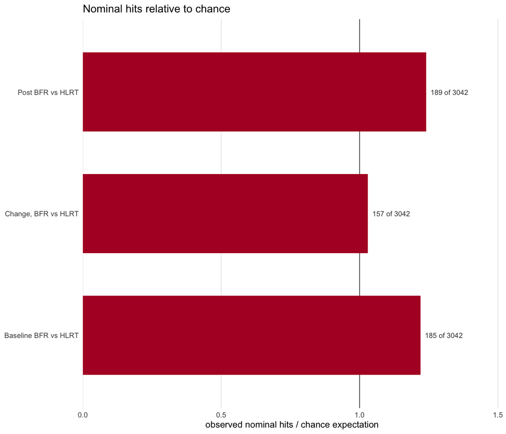

```r
chance_plot <- ggplot(chance_expectation, aes(ratio, task_label, fill = ratio > 1)) +
  geom_vline(xintercept = 1, linewidth = 0.4, colour = "grey40") +
  geom_col(width = 0.65) +
  geom_text(
    aes(label = sprintf("%d of %d", nominal, features)),
    hjust = -0.12, size = 2.5, colour = "grey25"
  ) +
  scale_fill_manual(values = c(`TRUE` = "#B2182B", `FALSE` = "grey72"), guide = "none") +
  scale_x_continuous(expand = expansion(mult = c(0, 0.22))) +
  labs(
    x = "observed nominal hits / chance expectation", y = NULL,
    title = "Nominal hits relative to chance"
  ) +
  figure_theme +
  theme(panel.grid.major.y = element_blank())
write_pdf(list(chance_plot), "04_chance.pdf")
chance_plot
```

## Cross-reference earlier steps

A candidate passes three bars: DE at FDR 0.05 in any contrast, association at nominal p with any outcome, and classification at nominal p after training or in change. Each protein gets eight association tests, so about a third of any list clears the association bar by chance.

```r
de_hits <- de |>
  select(protein, ends_with("adj.P.Val"), -starts_with("blood")) |>
  pivot_longer(-protein, names_to = "contrast", values_to = "de_fdr") |>
  filter(de_fdr < 0.05) |>
  summarise(
    de_contrasts = paste(sub("_adj.P.Val", "", contrast), collapse = "; "),
    best_de_fdr = min(de_fdr), .by = protein
  )
associated <- associations |>
  filter(p < 0.05) |>
  summarise(
    association = paste0(analysis, " ", outcome, " t ", sprintf("%+.2f", t), collapse = "; "),
    best_association_p = min(p), .by = protein
  )
classified <- protein_auc |>
  filter(p_paired < 0.05, task != "baseline_BFR_vs_HLRT") |>
  summarise(
    classification = paste0(task_label, " AUC ", sprintf("%.2f", auc), collapse = "; "),
    .by = protein
  )
c(de = nrow(de_hits), associated = nrow(associated), classified = nrow(classified))
```

```
        de associated classified
       262        761        296
```

Strongest association first.

```r
candidates <- de_hits |>
  inner_join(associated, by = "protein") |>
  inner_join(classified, by = "protein") |>
  mutate(gene = genes[protein], .after = protein) |>
  arrange(best_association_p)

nrow(candidates)
```

```
[1] 18
```

```r
head(select(candidates, protein, gene, best_de_fdr, best_association_p))
```

```
# A tibble: 6 × 4
  protein gene    best_de_fdr best_association_p
  <chr>   <chr>         <dbl>              <dbl>
1 O43852  CALU       3.45e- 2            0.00220
2 P12270  TPR        4.56e- 2            0.00448
3 Q9BVC6  TMEM109    4.18e- 2            0.00612
4 Q9NS86  LANCL2     4.18e- 2            0.00962
5 P43490  NAMPT      2.16e-10            0.0156
6 P31150  GDI1       3.41e- 2            0.0227
```

## Save results

`04_protein_classification.xlsx` holds the chance table, every protein’s AUC and p per task sorted by p, and the candidate list.

```r
write_xlsx(
  list(
    chance_expectation = chance_expectation,
    protein_auc = arrange(protein_auc, p_paired),
    candidates = candidates
  ),
  file.path(stage, "c_data", "04_protein_classification.xlsx")
)
```